# Lab9 - Ordered and Multinomial Logistic Regression

# Appendix: Simulation-based 95% Confidence Intervals for Predicted Probabilities from the Ordered Logistic Regression Model

As always, the material in the appendix is not required for the course and only provided for the curious. In this appendix, we tackle the problem of calculating confidence intervals for the predicted probabilities from the ordered logistic regression model.

To layout the procedure, we assume the usual regularity conditions and that that the model is correctly specified. Under these conditions,

$$\sqrt{n}(\hat{\boldsymbol\theta} - \boldsymbol \theta) \longrightarrow N(\mathbf 0, \mathcal I^{-1}(\boldsymbol\theta))$$

in distribution as $n \rightarrow \infty$ and where $\hat{\boldsymbol\theta} = [\hat{\boldsymbol\beta}, \hat{\boldsymbol\tau}]'$ is the maximum likelihood estimator of the regression coefficients and the threshold parameters, $\boldsymbol \theta = [\boldsymbol \beta, \boldsymbol\tau]'$ is a vector of the true coefficients, and $\mathcal I(\boldsymbol\theta)$ the Fischer Information matrix. In practice, we approximate the Fischer Information with the observed Fischer information, which is equal to the negative inverse of the Hessian matrix $\mathbf H$ (A small note: as the threshold parameters have to be ordered—i.e., $\tau_1 < \tau_2 < \cdots < \tau_{K-1}$—the model is often reparameterized to ensure the right ordering of these parameters. In this case, the negative inverted Hessian will not be equal to the observed Fischer information. For example, when we look into the `MASS:::vcov.polr` function, we see that a Jacobian adjustment is added to the Hessian. As we will rely on this function, rather than coding it ourselves, we will skip the discussion of these adjustments).

To obtain 95% confidence intervals for our predictions, we might rely on the following procedure.

1. As we know (using somewhat sloppy notation) that
   $$\hat{\boldsymbol \theta} \sim \text{Normal}(\boldsymbol\theta, n^{-1}\mathcal I(\hat{\boldsymbol\theta})^{-1})$$
   in large samples, we might draw $S$ simulation draws from this distribution. Call these draws $\boldsymbol\theta^{(1)}, \boldsymbol\theta^{(2)},..., \boldsymbol\theta^{(S)}$.
2. For each simulated $\boldsymbol\theta^{(s)}, s= 1,2,...,S$, we calculate the predicted probabilities at the values of $\mathbf X$ that we want. Suppose, for example, we want the interval for a specific value of predictors, which we denote by $\mathbf x^\ast$. Then,
   - the predicted logit would be $v^{(s)} = \mathbf x^\ast\boldsymbol\beta^{(s)}$.
   - the predicted probability of outcome $1$ at $\mathbf x^\ast$ is then
     $$\hat\pi_1^{(s)} = \Pr[Y_i = 1\,\vert\, \mathbf X_i = \mathbf x^\ast] = \Lambda(\tau_1; v^{(s)}, 1)$$
     where $\Lambda(a; b, c)$ is the Logistic CDF with location parameter $b$, scale parameter $c$, evaluated at the point $a$;
   - the predicted probability of outcome $j$, $1<j < K$, is
     $$\hat\pi_j^{(s)}\Pr[Y_i = j\,\vert\, \mathbf X_i = \mathbf x^\ast] = \Lambda(\tau_{j}; v^{(s)}, 1) - \Lambda(\tau_{j-1}; v^{(s)}, 1)$$
   - and the predicted probability of the outcome $K$ is
     $$\hat\pi_K^{(s)} = \Pr[Y_i = K\,\vert\, \mathbf X_i = \mathbf x^\ast] = 1- \Lambda(\tau_{K-1}; v^{(s)}, 1).$$
3. This will give us $S$ simulated values of $\hat\pi_{k}^{(s)}, k = 1,2,...,K$. For each $k$, we can then summarize the distribution of $\hat\pi_k^{(s)}$ using the simulation draws. For example, to obtain the 95% confidence intervals, we can calculate the $0.025$th and $0.975$th quantile of the distribution of $\hat\pi_k^{(s)}$ across the simulation draws.

This will give us a simulation based 95% confidence intervals. Coding this procedure in R is not too difficult (although also not too easy). I’ll use a different style here to document the function, which you’ll probably encounter when you look into the source code of other R functions. The lines starting with `#'` before the function definition are there to tell the reader what the function does. A `@param` line adds specific documents for each of the arguments that are passed to the function and the `@return` line documents what the function will return. After theses lines, the function is defined in the usual way.

```r
#' Confidence Intervals for Predictions of Ordered Logistic Regression Model
#'
#' A function to calculate simulation-based confidence intervals for predictions based on \code{MASS::polr} objects relying large-sample behavior of the MLE.
#'
#' @param m a \code{MASS::polr} object
#' @param newdata dataset that specifies the values for which predictions should be made
#' @param level the \eqn{\alpha}-level
#' @param n_sim number of simulation draws to use
#' @param return_fit if TRUE, the function returns also the point estimates; otherwise, only confidence intervals are returned
#' @param return_list if TRUE, a \code{list} object is returned; otherwise, the function returns an \code{array}
#' @return a list of length \code{K}, where \code{K} is the number of ordered categories of the dependent variable. Each element of this list is a \code{n} times \code{m} matrix, where \code{n} is the number of points at which the predictionis made and \code{m} is either 3 (if \code{return_fit = FALSE}) or 2.

sim_ci_pred_polr = function(
    m,
    newdata,
    level,
    n_sim = 1000,
    return_fit = TRUE,
    return_list = TRUE)
{

    # check whether required packages are installed
    if (!requireNamespace("abind"))
        stop("Install abind to use function")

    # transform newdata into matrix
    X = as.matrix(newdata)

    # get coefs
    beta = coef(m)
    n_beta = length(beta)

    # get thresholds and augment with inf
    tau = m$zeta
    n_cat = length(tau) + 1L

    # get variance-covariance matrix
    Sigma = vcov(m)

    message(
        paste0("Calculating ", 100 * level,
               "% confidence intervals with ",
               n_sim,
               " simulation draws ... ")
    )

    # simulate coefficients from multivariate Normal dist.
    sim_res = MASS::mvrnorm(
        n_sim,
        mu = c(beta, tau),
        Sigma = Sigma)

    # for each of simulated coefs, make predictions
    pred = lapply(1:nrow(sim_res), function(w) {

        # linear predictor
        xb = X %*% sim_res[w, 1:n_beta]

        # augmented threshold vector
        aug_tau = c(
            -Inf,
            sim_res[w, (n_beta + 1):ncol(sim_res)],
            Inf)

        # empty matrix to store results
        P = matrix(NA, nrow = nrow(X), ncol = n_cat)

        # fill with predicted probs
        for (i in 2:length(aug_tau)) {

            P[, i - 1L] = plogis(aug_tau[i], xb) -
                plogis(aug_tau[i - 1L], xb)

        }

        return(P)

    })

    # transform to array
    pred_arr = simplify2array(pred)

    # get lower and upper bound probs
    lo = 0.5 * (1 - level)
    hi = 1 - lo

    # calculate CIs
    ci = apply(pred_arr, 1:2, quantile, probs = c(lo, hi))

    if (return_fit) {

        # linear predictor
        xb = X %*% beta
        aug_tau = c(-Inf, tau, Inf)

        P = matrix(NA, nrow = nrow(X), ncol = n_cat)

        for (i in 2:length(aug_tau)) {

            P[, i - 1L] = plogis(aug_tau[i], xb) -
                plogis(aug_tau[i - 1L], xb)


        }

        # add fit and re-arrange
        res = aperm(
            abind::abind(P, ci, along = 1L),
            c(2, 1, 3)
        )

        # add dimension names
        dimnames(res) = list(
            NULL,
            c("fit", "lower", "upper"),
            paste0("outcome_", 1:n_cat)
        )


    } else {

        # re-arrange
        res = aperm(ci, c(2, 1, 3))

        # add dimension names
        dimnames(res) = list(
            NULL,
            c("lower", "upper"),
            paste0("outcome_", 1:n_cat)
        )

    }

    if (!return_list)
        return(res)

    # transform back to list
    res_list = lapply(
        seq.int(dim(res)[3]), function(w) res[ , , w]
    )

    # add names
    names(res_list) = dimnames(res)[[3]]

    return(res_list)

}
```

Using this function, we can calculate and plot the 95% CIs of our predictions:

```r
set.seed(52432)

# obs
n = 5000

# coefficients
beta = c(.8, .25)

# thresholds
tau = c(-.5, 2)

# predictors (dummy & continuous)
x1 = sample(c(0, 1), n, replace = T)
x2 = runif(n, -2, 2)

# generate latent outcome
ystar = x1 * beta[1] + x2 * beta[2] + rlogis(n)

# generate obseved outcome
y = ifelse(
    ystar < tau[1], 1,
        ifelse(ystar >= tau[1] & ystar < tau[2], 2, 3)
)

# construct dataset
olog_dat = data.table(y, x1, x2)

# refit model
refit = MASS::polr(factor(y) ~ x1 + x2, data = olog_dat,
                   Hess = T)

# dataset to make predictions
new_dat = data.table(x1 = 1, x2 = seq(-2, 2, .1))

# get predictions and CIs
ci = sim_ci_pred_polr(
    m = refit,          # model
    newdata = new_dat,  # data for which preds are made
    level = .95,        # desired confidence level
    n_sim = 1000)       # number of sims to use
```

```
## Calculating 95% confidence intervals with 1000 simulation draws ...
```

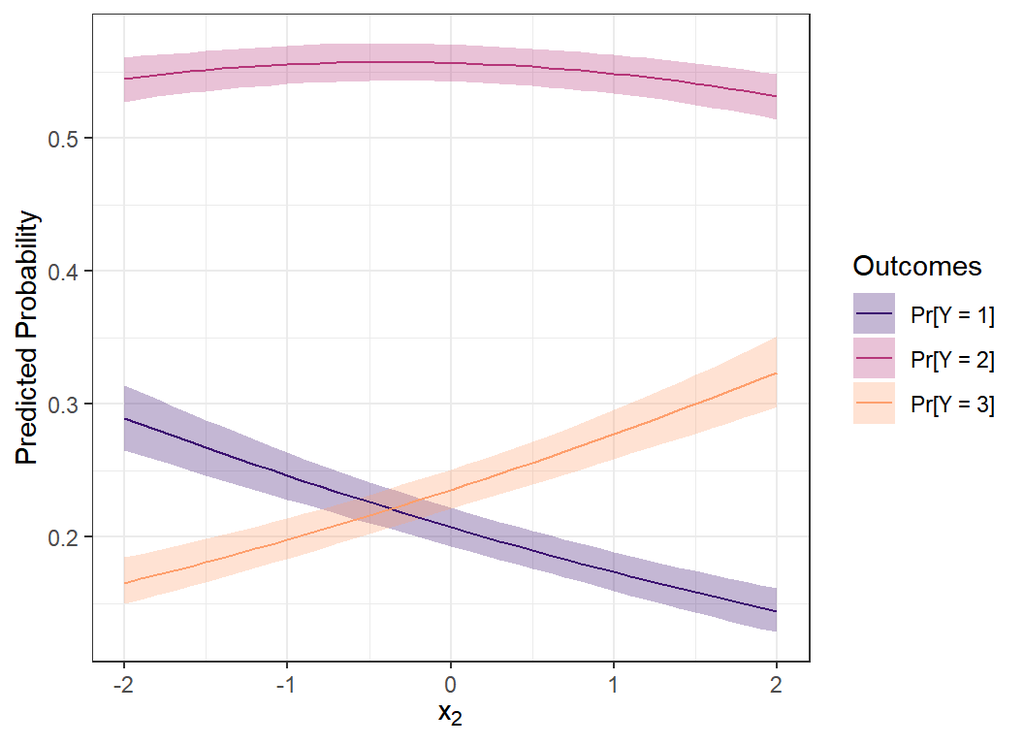

```r
# combine list to data.table
#
# note: the do.call function calls the function rbind
#       on the list ci. It will `rbind` each of the elements
#       in the ci object together, so that the first element
#       in ci (which is a matrix of predictions for the
#       outcome Y = 1) on top of the second element (which
#       contains the predictions for the outcome Y = 2),
#       and so on.
pred_dat = do.call(rbind, ci) %>%
    as.data.table

# add outcome column and column for predictor values
#
# note: as mentioned repeatedly throughout the course, when
#       you are not `merge`ing datasets, but assign columns
#       by your self directly, you have to be 100% sure that
#       the rows of your original dataset indeed correspond
#       to the rows of your added columns. In this case,
#       we are 100% sure, since we have created the object
#       ourselves. In the case you are uncertain, you should
#       always check the resulting object.

pred_dat[, `:=`(
    outcome = rep(1:3, each = nrow(new_dat)),
    x2 = rep(new_dat$x2, 3)
)]


# change outcome to factor with appropriate labels
pred_dat[
    , outcome := factor(
        outcome,
        levels = 1:3,
        labels = paste0("Pr[Y = ", 1:3, "]"))
    ]


# plot
ggplot(pred_dat, aes(x = x2, y = fit, col = outcome)) +
    geom_ribbon(
        aes(ymin = lower, ymax = upper, fill = outcome),
        col = NA, alpha = .3,
        inherit.aes = T
    ) +
    geom_line() +
    theme_bw() +
    labs(x = expression(x[2]), y = "Predicted Probability") +
    scale_color_viridis_d(
        name = "Outcomes",
        begin = .2,
        end = .8,
        option = "A") +
    scale_fill_viridis_d(
        name = "Outcomes",
        begin = .2,
        end = .8,
        option = "A")
```

We see that the predicted probabilities are precisely estimated—i.e., the confidence intervals tendt to be narrow—which is also expected as we have a sample size of `n = 5000`. A similar approach can be used for the multinomial logit model. I’ll leave that as a future exercise to you.

Another question that is important to pursue whenever you create your own function to estimate something like confidence intervals is whether these intervals indeed contain the true parameter with the correct confidence level over repeated samples. This question is examined separately [somewhere else](https://barumpark.com/blog/2019/Ologit-Predict/); you might follow that link if you are curious.